# Praca domowa 2

Rozalia Wróblewska

## Dane

Dane wykorzystane w Pracy domowej 2 dotyczą wyników egzaminów z 3 umiejętności: czytania, pisania i operacji matematycznych. Dodatkowo dostępne są podstawowe informacje o studentach i ich rodzicach. Opis wszystkich kolumn znajduje się również w pliku `README.md`.

| Zmienna | Opis |
| --- | --- |
| **gender** | płeć |
| **race.ethnicity** | pochodzenie etniczne |
| **parental.level.of.education** | wykształcenie rodziców |
| **lunch** | jaki obiad jedli uczniowie w dniu egzaminu |
| **test.preparation.course** | czy uczeń odbył kurs przygotowujący |
| **math.score** | wynik egzaminu z matematyki |
| **reading.score** | wynik egzaminu z czytania |
| **writing.score** | wynik egzaminu z pisania |

## Zadanie 1

Jak wyglądają rozkłady wyników uczniów z trzech przedmiotów (matematyka, czytanie, pisanie)?

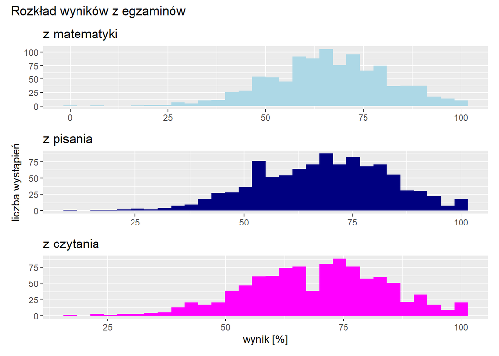

```r
ggplot(df, aes(x = math.score)) + geom_histogram(fill = 'lightblue') +
  labs(title = "z matematyki") -> a1
a1 <- a1 + labs(x = NULL, y = NULL)
ggplot(df, aes(x = writing.score)) + geom_histogram(fill = 'navy') +
  labs(title = "z pisania") -> a2
a2 <- a2 + labs(x = NULL, y = "liczba wystąpień")
ggplot(df, aes(x = reading.score)) + geom_histogram(fill = 'magenta') +
  labs(title = "z czytania") -> a3
a3 <- a3 + labs(x = NULL, y = NULL)

(a1 / a2 / a3) + plot_layout(guides = "collect") + plot_annotation(title = "Rozkład wyników z egzaminów") +
  theme(axis.title.x = element_text(), axis.title.y = element_text()) +
  labs(x = "wynik [%]")
```

**Komentarz:**

Rozkłady z matematyki, pisania i czytania wyglądają podobnie - są zbliżone do rozkładu normalnego, przesuniętego w prawo.

Jednak w przypadku matematyki znaczna część wyników mieści się w przedziale od 60 % do 80 %, podczas gdy w pozostałych przedmiotach nie ma takiej przewagi wyników w tym przedziale.

W rozkładzie wyników z czytania można zauważyć, że dla wyniku około 70 % jest znaczny spadek liczby wystąpień.

## Zadanie 2

Czy istnieje zauważalna różnica w wynikach między uczniami i uczennicami?

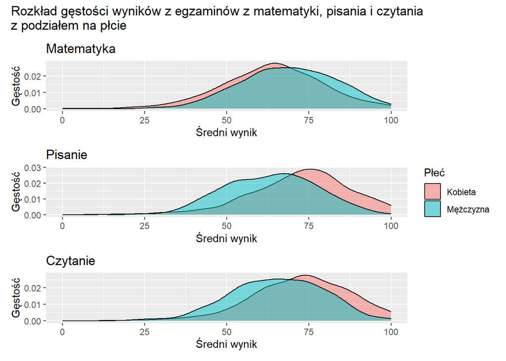

```r
df %>%
  ggplot(aes(x = math.score, fill = gender)) +
  geom_density(alpha = 0.5) +
  labs(title = "Matematyka",
       fill = "Płeć") +
  xlab("Średni wynik") +
  ylab("Gęstość") +
  scale_fill_discrete(labels = c("female" = "Kobieta", "male" = "Mężczyzna")) -> p1

df %>%
  ggplot(aes(x = writing.score, fill = gender)) +
  geom_density(alpha = 0.5) +
  labs(title = "Pisanie",
       fill = "Płeć") +
  xlab("Średni wynik") +
  ylab("Gęstość") +
  scale_fill_discrete(labels = c("female" = "Kobieta", "male" = "Mężczyzna")) +
  scale_x_continuous(limits = c(0,100)) -> p2

df %>%
  ggplot(aes(x = reading.score, fill = gender)) +
  geom_density(alpha = 0.5) +
  labs(title = "Czytanie",
       fill = "Płeć") +
  xlab("Średni wynik") +
  ylab("Gęstość") +
  scale_fill_discrete(labels = c("female" = "Kobieta", "male" = "Mężczyzna")) +
  scale_x_continuous(limits = c(0,100)) -> p3

p1 / p2 / p3 + plot_layout(guides = "collect") + plot_annotation(title = "Rozkład gęstości wyników z egzaminów z matematyki, pisania i czytania\nz podziałem na płcie")
```

**Komentarz:**

W rozkładzie gęstości każdego z przedmiotów istnieje zauważalna różnica między wynikami uczniów i uczennic.

Wyniki egzaminu z matematyki świądczą o większych umiejętnościach chłopaków niż dziewczyn w tym przedmiocie, jednak jest to niewielka różnica.

Egzamin z pisania i czytania znacznie lepiej poszedł dziewczynom - osiągały one średnio o 5-10 % wyższy wynik niż chłopacy.

## Zadanie 3

Czy uczniowie, którzy ukończyli kurs przygotowawczy, osiągają lepsze wyniki niż pozostali?

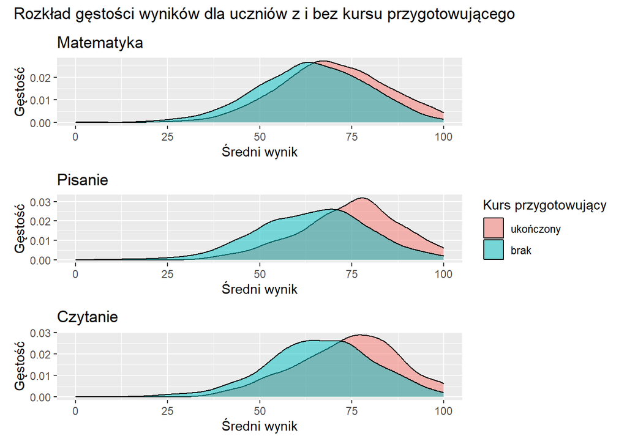

```r
df %>%
  ggplot(aes(x = math.score, fill = test.preparation.course)) +
  geom_density(alpha = 0.5) +
  labs(title = "Matematyka", fill = "Kurs przygotowujący") +
  xlab("Średni wynik") +
  ylab("Gęstość") +
  scale_fill_discrete(labels = c("none" = "brak", "completed" = "ukończony")) ->w1

df %>%
  ggplot(aes(x = writing.score, fill = test.preparation.course)) +
  geom_density(alpha = 0.5) +
  labs(title = "Pisanie", fill = "Kurs przygotowujący") +
  xlab("Średni wynik") +
  ylab("Gęstość") +
  scale_fill_discrete(labels = c("none" = "brak", "completed" = "ukończony")) +
  scale_x_continuous(limits = c(0,100)) ->w2

df %>%
  ggplot(aes(x = reading.score, fill = test.preparation.course)) +
  geom_density(alpha = 0.5) +
  labs(title = "Czytanie", fill = "Kurs przygotowujący") +
  xlab("Średni wynik") +
  ylab("Gęstość") +
  scale_fill_discrete(labels = c("none" = "brak", "completed" = "ukończony")) +
  scale_x_continuous(limits = c(0,100)) ->w3

w1 / w2 / w3 + plot_layout(guides = "collect") + plot_annotation(title = "Rozkład gęstości wyników dla uczniów z i bez kursu przygotowującego")
```

**Komentarz:**

Uczniowie, którzy ukończyli kurs przygotowyjący osiągają średnio lepsze wyniki niż uczniowie bez żadnego kursu. W przypadku egzaminu z matematyki różnica w rozkładzie gęstości wyników dla uczniów z ukończonym kursem i bez nie przekracza przesunięcia o 6 % na korzyść uczniów z ukończonym kursem. Dla egzaminu z pisania i czytania widoczne jest, że uczniowie z kursem wypadają dużo lepiej.

## Zadanie 4

Jaki jest związek między poziomem wykształcenia rodziców a średnimi wynikami uczniów?

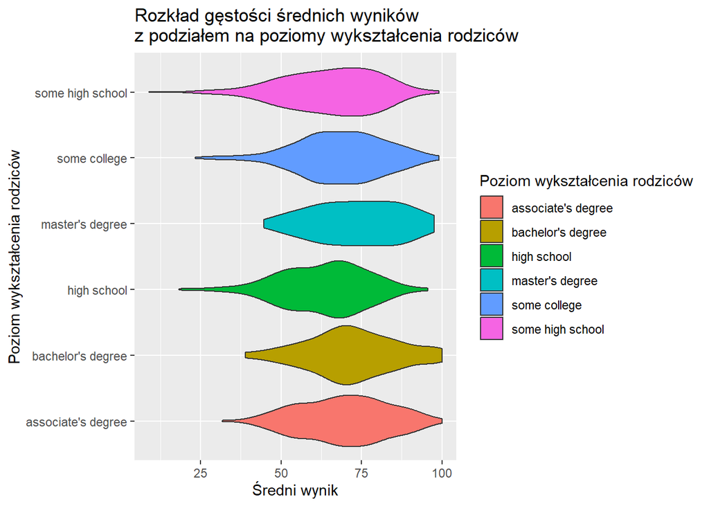

```r
df %>%
  mutate(mean.score = (math.score + writing.score + reading.score)/3) %>%
  ggplot(aes(x = mean.score, y = parental.level.of.education, fill = parental.level.of.education)) +
  geom_violin() +
  labs(title = "Rozkład gęstości średnich wyników\nz podziałem na poziomy wykształcenia rodziców", fill = "Poziom wykształcenia rodziców") +
  xlab("Średni wynik") +
  ylab("Poziom wykształcenia rodziców") +
  theme(plot.title = element_text(hjust = 0))
```

**Komentarz:**

Poziom wykształcenia rodziców ma widoczny wpływ na średni wynik z egzaminów.

Średnio najlepsze wyniki osiągają dzieci rodziców z dyplomem magisterskim, chociaż żadne z nich nie napisało wszystkich 3 egzaminów na 100 % - w przeciwieństwie do dzieci licencjatów i współpracowników (associate’s degree).

## Zadanie 5

Czy płeć i wykształcenie rodzica wpływa na wynik z matematyki?

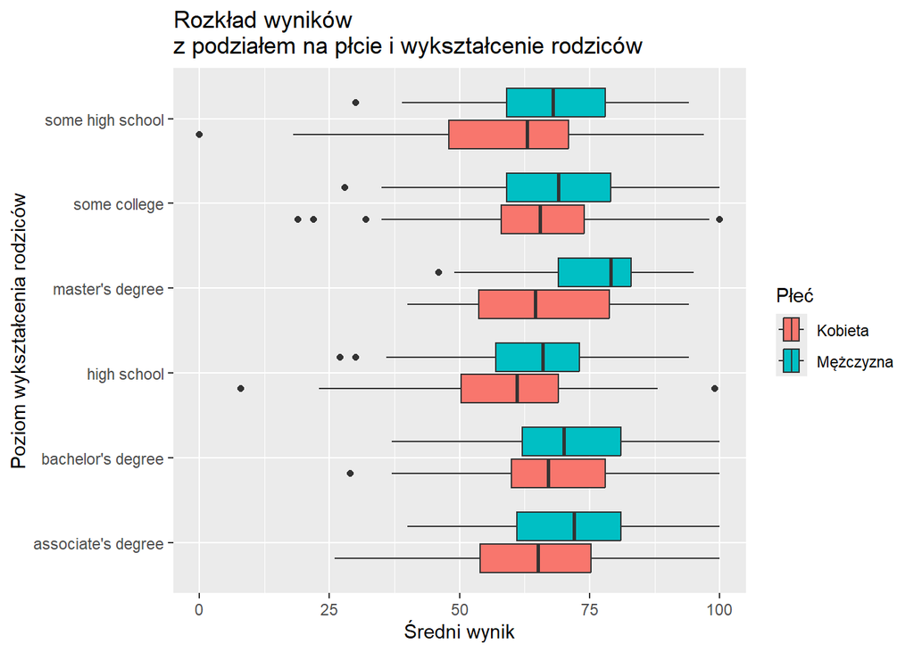

```r
df %>%
  ggplot(aes(x = math.score, y = parental.level.of.education, fill = gender)) +
  geom_boxplot() +
  labs(title = "Rozkład wyników\nz podziałem na płcie i wykształcenie rodziców",
       fill = "Płeć") +
  xlab("Średni wynik") +
  ylab("Poziom wykształcenia rodziców") +
  theme(plot.title = element_text(hjust = 0)) +
  scale_fill_discrete(labels = c("female" = "Kobieta", "male" = "Mężczyzna"))
```

**Komentarz:**

Można zauważyć wpływ płci na wynik z matematyki - dla każdego poziomu wykształcenia rodziców to chłopaki lepiej pisały egzamin.

Dzieci magistrów w większości pisały egzamin z matematyki na ponad 60 %, jednak żadne z nich nie osiągneło maksimum punktów.

Średnio najsłabsze wyniki z matematyki dostały dzieci rodziców z wykształceniem średnim.

## Zadanie 6

Czy istnieje zależność między wynikami z matematyki a wynikami z czytania lub pisania?

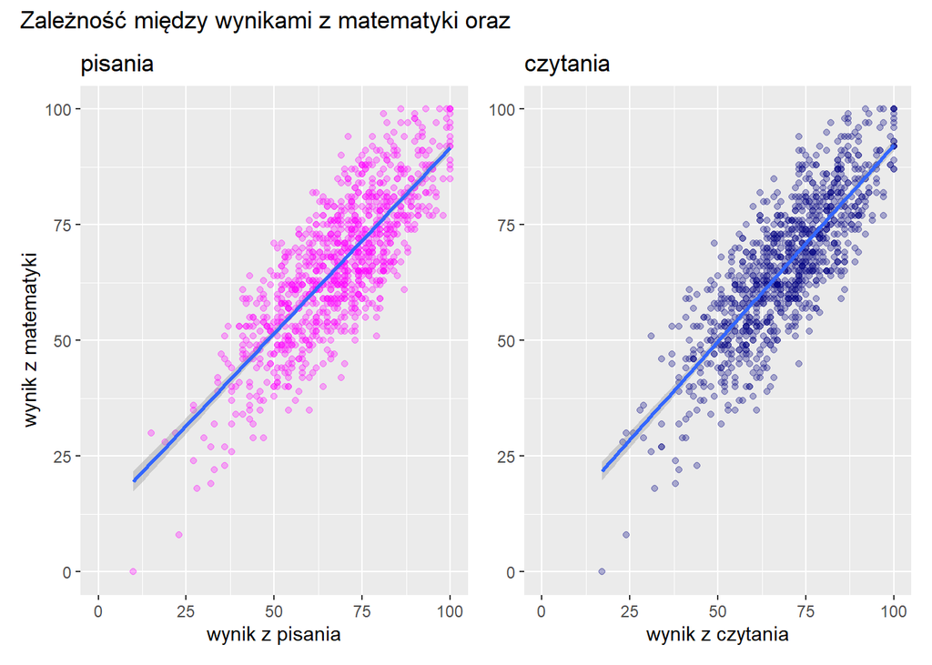

```r
df %>%
  ggplot(aes(y = math.score, x = writing.score)) +
  labs(title = "pisania",
       y = "wynik z matematyki", x = "wynik z pisania") +
  geom_point(color = "magenta", alpha = 0.3) +
  scale_y_continuous(limits = c(0,100)) +
  scale_x_continuous(limits = c(0,100)) +
  geom_smooth(method = "lm", se = TRUE)-> b1

df %>%
  ggplot(aes(y = math.score, x = reading.score)) +
  labs(title = "czytania",
       y = "wynik z matematyki", x = "wynik z czytania") +
  geom_point(color = "navy", alpha = 0.3) +
  scale_y_continuous(limits = c(0,100)) +
  scale_x_continuous(limits = c(0,100)) +
  geom_smooth(method = "lm", se = TRUE)-> b2
b2 <- b2 + labs(y = NULL)


(b1 + b2) + plot_layout(guides = "collect") + plot_annotation(title = "Zależność między wynikami z matematyki oraz")
```

**Komentarz:**

Istnieje zależność między wynikami z matematyki, i czytania, i pisania - zależność liniowa. Nikt nie napisał egzaminu z czytania lub pisania na 0 %, a zdarzało się to dla matematyki.

Więcej osób osiągnęło maksymalny wynik dla pisania lub czytania niż dla matematyki.